# Microbiome Analysis

MOL.923 Computerlabor Bioinformatik (WS 2025)

25/11/2025

## Background

What is the influence of genotype (intrinsic) and environment (extrinsic) on anemone-associated bacterial communities?

### The Players

- *Exaiptasia diaphana* - a shallow-water, marine anemone that is often used in research as a model organism for corals. In this experiment, two genotypes (AIMS1 and AIMS4) of *E. diaphana* were grown in each of two different environments:
  1. sterile seawater *OR*
  2. unfiltered control seawater
- The anemone-associated bacterial communities or *microbiome* - these bacteria live on, or within *E. diaphana*, and likely consist of a combination of commensals, transients, and long-term stable members, and combined with their host, form a mutually beneficial, stable symbiosis.

### The Study

The anemone microbiome contributes to the overall health of this complex system and can evolve in tandem with the anemone host. In this data set we are looking at the impact of intrinsic and extrinsic factors on anemone microbiome composition. After three weeks in either sterile or control seawater (environment), anemones were homogenized and DNA was extracted. There are *23* samples in this data set - *5* from each anemone treatment combination (2 genotypes x 2 environments) and *3* DNA extraction blanks as controls. *This data is a subset from a larger experiment*.

Dungan AM, van Oppen MJH, and Blackall LL (2021) Short-Term Exposure to Sterile Seawater Reduces Bacterial Community Diversity in the Sea Anemone, *Exaiptasia diaphana*. *Front. Mar. Sci.* 7:599314. doi:10.3389/fmars.2020.599314 [[Full Text]](https://www.frontiersin.org/articles/10.3389/fmars.2020.599314/full).

First we load some packages

```r
library(scater)
library(mia)
library(miaViz)
library(patchwork)
library(vegan)
```

First of all, we import data from qiime2 into R

```r
featureTableFile <- "data/table.qza"
taxonomyTableFile <- "data/taxonomy.qza"
sampleMetaFile <- "data/metadata.tsv"
phyTreeFile <- "data/16s_rooted_tree.qza"

tse <- importQIIME2(
  featureTableFile = featureTableFile,
  taxonomyTableFile = taxonomyTableFile,
  sampleMetaFile = sampleMetaFile,
  phyTreeFile = phyTreeFile
)

tse
```

```
## class: TreeSummarizedExperiment
## dim: 557 23
## metadata(0):
## assays(1): counts
## rownames(557): 53818a706e38c1584f139d2f90fbd8df
##   062b090c083845612e0ed7dc400c9106 ... f96524240d0c7e6c19bc0e3f7eb068a9
##   bd7ffe913695618020ca3db344280988
## rowData names(8): kingdom phylum ... species Confidence
## colnames(23): AN10 AN22 ... CTRLB CTRLC
## colData names(6): ID TypeofSample ... Forward Reverse
## reducedDimNames(0):
## mainExpName: NULL
## altExpNames(0):
## rowLinks: a LinkDataFrame (557 rows)
## rowTree: 1 phylo tree(s) (557 leaves)
## colLinks: NULL
## colTree: NULL
```

## Abundance

First we explore the data a bit and explore the abundance.

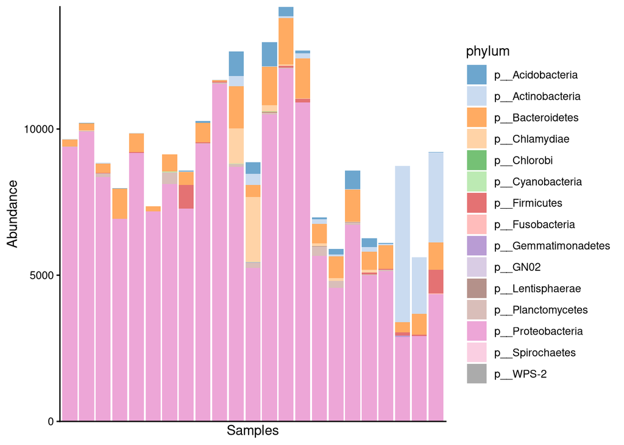

```r
plotAbundance(tse, assay.type="counts", group = "phylum")
```

## Alpha Diversity

### Estimation

```r
# estimate the specified indices based on the counts assay

tse <- addAlpha(tse)
```

## Visualisation

```r
colnames(colData(tse))
```

```
##  [1] "ID"                "TypeofSample"      "Genotype"
##  [4] "Environment"       "Forward"           "Reverse"
##  [7] "dbp_dominance"     "faith_diversity"   "observed_richness"
## [10] "shannon_diversity"
```

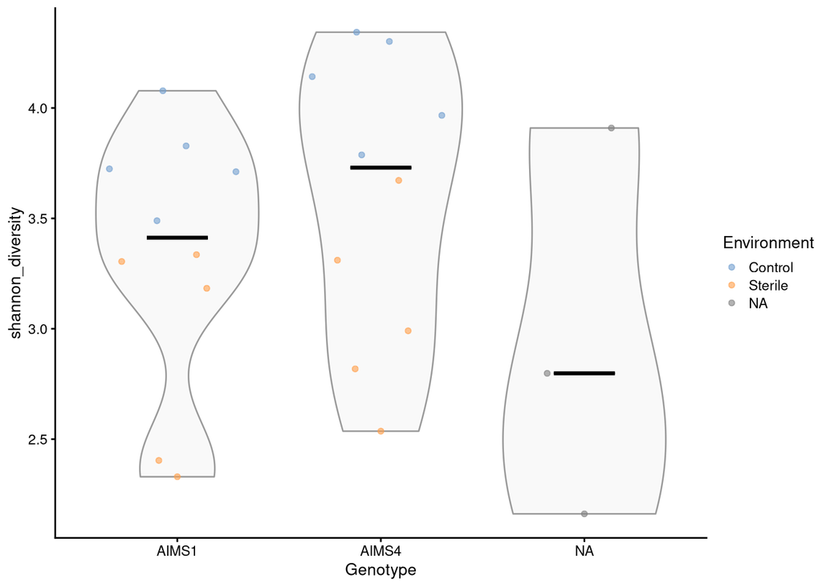

```r
# plot shannon diversity vs patient_status
p_shannon <- plotColData(tse, "shannon_diversity", "Genotype",
                          colour_by = "Environment", show_median = TRUE) +
  labs(x = "Genotype")
p_shannon
```

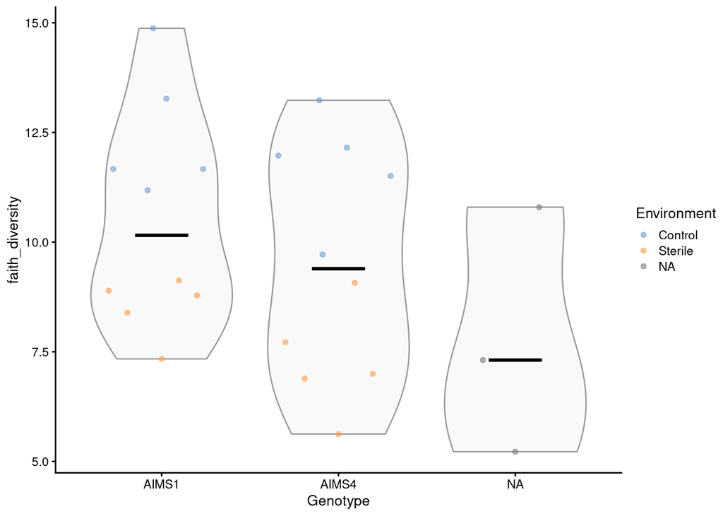

```r
# plot faith index vs patient_status
p_faith <- plotColData(tse, "faith_diversity", "Genotype",
                          colour_by = "Environment", show_median = TRUE) +
  labs(x = "Genotype")
p_faith
```

## Testing for differences between groups

We can extract a `data.frame` from the object `tse`. We use the factor command to define groups for the *Genotype* and the *Environment*.

```r
col_dat <- colData(tse)
col_dat$Genotype <- factor(col_dat$Genotype)
col_dat$Environment <- factor(col_dat$Environment)
```

Now we can test if there are differences between the environments or genotype. First we test if there are differences between the genotype. We also plot the the data using a boxplot and violin plot.

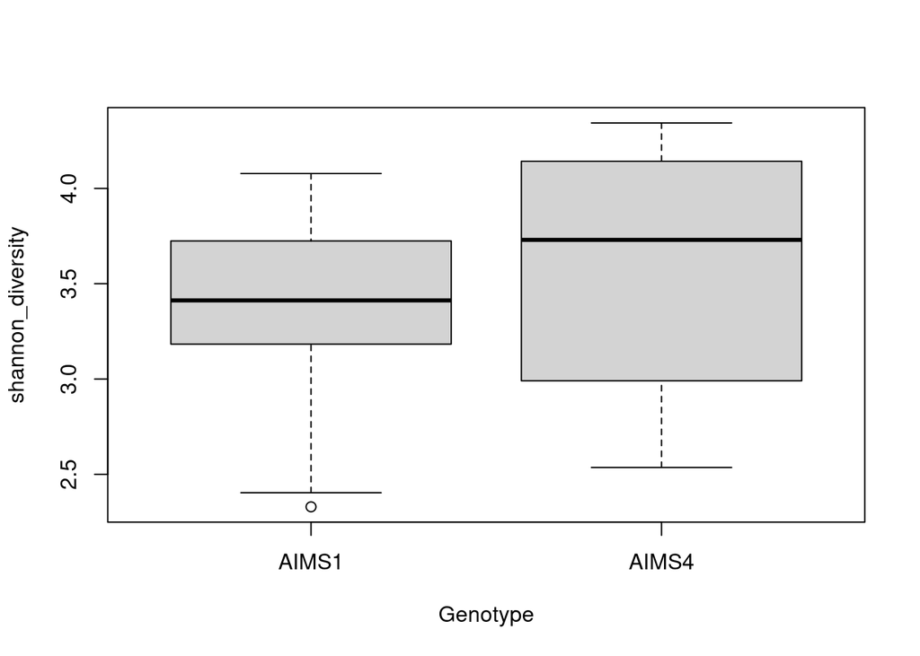

```r
plot(shannon_diversity ~ Genotype, col_dat)
```

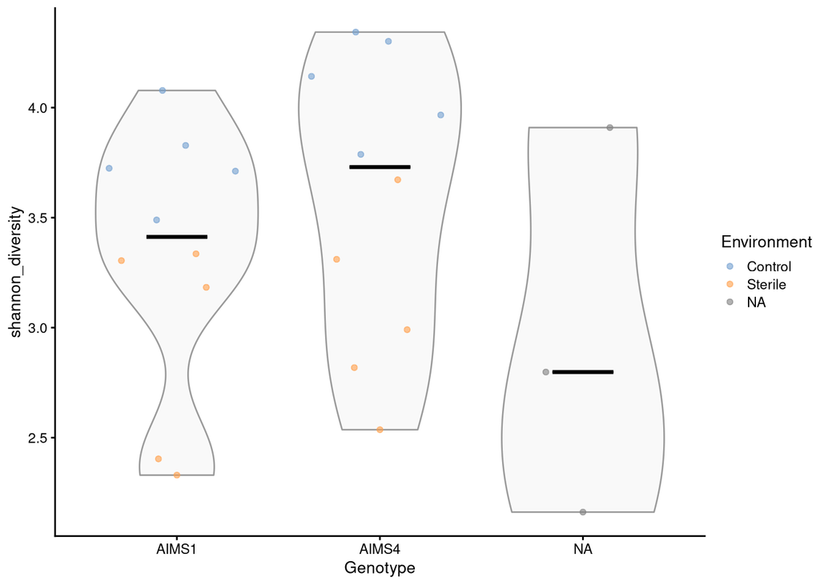

```r
p_shannon
```

```r
wilcox.test(shannon_diversity ~ Genotype, col_dat)
```

```
##
##  Wilcoxon rank sum exact test
##
## data:  shannon_diversity by Genotype
## W = 37, p-value = 0.3527
## alternative hypothesis: true location shift is not equal to 0
```

```r
t.test(shannon_diversity ~ Genotype, col_dat)
```

```
##
##  Welch Two Sample t-test
##
## data:  shannon_diversity by Genotype
## t = -0.90764, df = 17.81, p-value = 0.3762
## alternative hypothesis: true difference in means between group AIMS1 and group AIMS4 is not equal to 0
## 95 percent confidence interval:
##  -0.8227698  0.3265980
## sample estimates:
## mean in group AIMS1 mean in group AIMS4
##            3.338834            3.586919
```

For the genotype at an significance level $\alpha=0.05 \%$ we cannot reject the Null hypothesis that the groups are equal. The p-value (Wilcoxon test: 0.3527 and t-test: 0.3762) is greater than $\alpha=0.05 \%$. This does not suggest that these groups do not differ. The differences might be too small to identify with the small sampling size we have.

Next we test if there is a difference between the two environments.

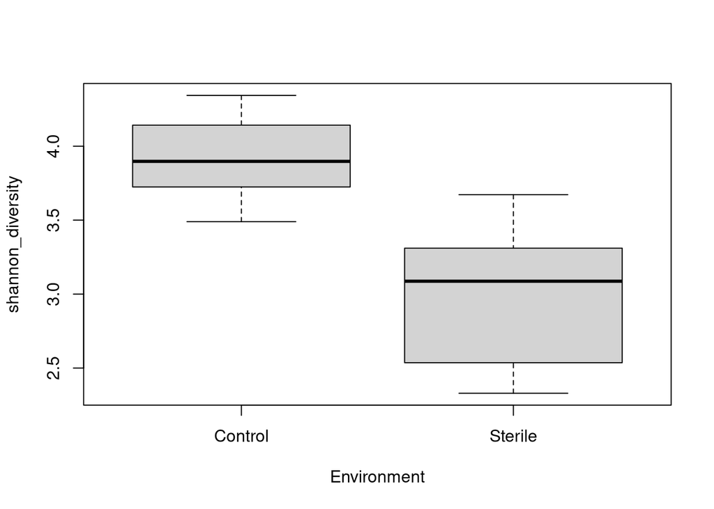

```r
plot(shannon_diversity ~ Environment, col_dat)
```

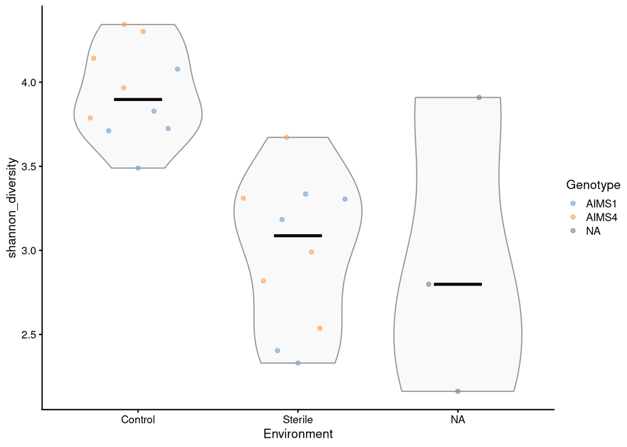

```r
p_shannon <- plotColData(tse, "shannon_diversity", "Environment",
                          colour_by = "Genotype", show_median = TRUE) +
  labs(x = "Environment")
p_shannon
```

```r
wilcox.test(shannon_diversity ~ Environment, col_dat)
```

```
##
##  Wilcoxon rank sum exact test
##
## data:  shannon_diversity by Environment
## W = 99, p-value = 2.165e-05
## alternative hypothesis: true location shift is not equal to 0
```

```r
t.test(shannon_diversity ~ Environment, col_dat)
```

```
##
##  Welch Two Sample t-test
##
## data:  shannon_diversity by Environment
## t = 5.6581, df = 14.929, p-value = 4.63e-05
## alternative hypothesis: true difference in means between group Control and group Sterile is not equal to 0
## 95 percent confidence interval:
##  0.5912145 1.3063373
## sample estimates:
## mean in group Control mean in group Sterile
##              3.937264              2.988489
```

For the environment the the p-values are smaller than $\alpha=0.05 \%$ (Wilcoxon test:2.165e-05 and t-test: 4.63e-05). In this case we can reject the null hypotheses and conclude that the two groups differ.

We can also perform an ANOVA (ANalysis Of VAriance). This allows us to test both dependent variables Environment and Genotype together.

```r
my_anova <- aov(shannon_diversity ~ Environment + Genotype, col_dat)
summary(my_anova)
```

```
##             Df Sum Sq Mean Sq F value   Pr(>F)
## Environment  1  4.501   4.501  34.421 1.87e-05 ***
## Genotype     1  0.308   0.308   2.353    0.143
## Residuals   17  2.223   0.131
## ---
## Signif. codes:  0 '***' 0.001 '**' 0.01 '*' 0.05 '.' 0.1 ' ' 1
## 3 Beobachtungen als fehlend gelöscht
```

Now we can see (again), that there is a statistical significant effect for the Environment, but not for the Genotype.

## Beta Diversity

### Principal Coordinate Analysis (PCoA)

PCoA is a method to choose the dimensions of the data that explain most of the variance in the data. Distances between samples can be expressed by several ecological indices, such as Bray-Curtis and Aitchison dissimilarities.

Here, we run multi-dimensional scaling (a type of PCoA) with Bray-Curtis dissimilarity and based on the relabundance assay.

We transform the counts assay to relative abundances and store the new assay back in the TreeSE.

```r
tse <- transformAssay(tse,
                       method = "relabundance")
```

```r
tse <- runMDS(tse,
              FUN = vegan::vegdist,
              method = "bray",
              name = "Bray",
              assay.type = "relabundance")
```

We then visualise the first two dimensions.

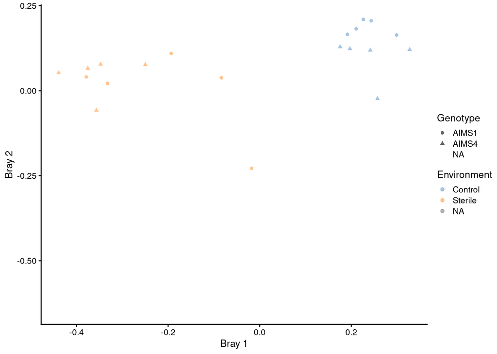

```r
p1 <- plotReducedDim(tse, "Bray",
                     colour_by = "Environment",
                     shape_by = "Genotype")

p1
```

We do the same for the Unifrac distance.

```r
tse <- runMDS(tse,
              FUN = mia::calculateUnifrac,
              name = "Unifrac",
              tree = rowTree(tse),
              ntop = nrow(tse),
              assay.type = "counts")
```

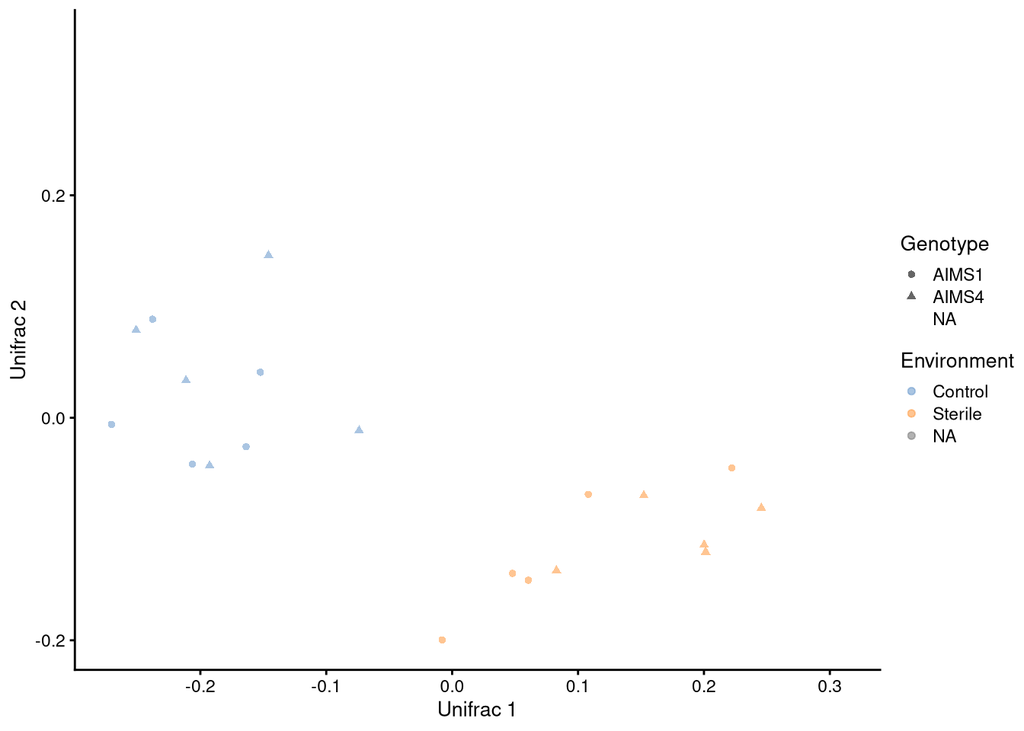

```r
p2 <- plotReducedDim(tse, "Unifrac",
                     colour_by = "Environment",
                     shape_by = "Genotype")

p2
```